# A Comparative Analysis of Student GPA and Career Readiness in 2026

An Analysis of Usage Patterns and Academic Performance

Author

Rico Araojo

Published

April 20, 2026

## 1 Objective

To evaluate whether the widespread adoption of LLMs in higher education functions primarily as a tool for academic stabilization and time management, and to determine if this technical integration translates into measurable professional confidence or if such confidence remains dependent on human-centric, non-computable traits.

## 2 Summary

The “How AI is Changing Life | AI and Student Life 2026” dataset, sourced from Kaggle, provides a simulated exploration of the impact of Artificial Intelligence on higher education. Artificially generated by Sohaib Malik for educational purposes, this dataset serves as a proxy for analyzing modern academic trends, AI tool adoption, and student performance metrics in a mid-2020s context.

Variable Definitions and Structural Metadata

| Fields | Definition | Data Type/Format |
| --- | --- | --- |
| Student_ID | A unique identifier for each student. | character |
| Primary_AI_Tool | The main AI platform the student uses for academic work. | character |
| GPA_Baseline | The student's Grade Point Average before integrating AI into their study routine. | numeric |
| AI_Ethics_Concern | Level of concern regarding academic integrity and original work (Low/Medium/High). | character/factor |
| Age | Age of the student, ranging from 18 to 25 years. | numeric |
| Task_Frequency_Daily | Estimated number of times a student interacts with AI tools per day. | numeric |
| GPA_Post_AI | The student's current Grade Point Average after adopting AI tools. | numeric |
| Career_Confidence_Score | Self-reported score (1-10) on how prepared the student feels for an AI-driven job market. | numeric/factor |
| Major | The student's field of study (e.g., Software Engineering, Business, Arts). | character |
| Main_Usage_Case | The primary way AI is utilized (e.g., Debugging, Research, Exam Prep). | character |
| Time_Saved_Hours_Weekly | Estimated hours saved per week by using AI for manual or repetitive tasks. | numercic |

## 4 Exploratory Data Analysis

#### 4.0.1 Regression Model

The **regression analysis** examines factors influencing a Career Confidence Score based on a sample of 1,500 observations. The model looks at specific majors, task frequency, and time saved to see what correlates with professional confidence.

The model suggests that academic background specifically Business and Data Science plays a small but measurable role in how confident individuals feel about their careers. However, because the Adjusted $R^2$ is 0.004, this model is a very weak predictor of overall confidence. While the intercepts and certain majors are technically significant, they represent only a tiny piece of the overall “confidence puzzle”.

|  | Career Confidence Score (1) Est. | Career Confidence Score (1) p |
| --- | --- | --- |
| (Intercept) | 4.998*** | &lt;0.001 |
| Daily Task Frequency | 0.026 | 0.310 |
| Business Administration | 0.532* | 0.034 |
| Data Science Major | 0.525* | 0.035 |
| Fine Arts | 0.478+ | 0.055 |
| Modern History | −0.098 | 0.706 |
| Software Engineering | 0.138 | 0.587 |
| Weekly Hours Saved | 0.001 | 0.961 |
| Num.Obs. | 1500 |  |
| R2 | 0.009 |  |
| R2 Adj. | 0.004 |  |

+ p < 0.1, * p < 0.05, ** p < 0.01, *** p < 0.001

#### 4.0.2 Shift in Academic Distribution

There is a visible reduction in the frequency of scores between the 2.5 and 2.8 range in the Post-AI group compared to the Baseline. This suggests that students who previously occupied the lower end of the spectrum have moved toward the middle or higher tiers of the distribution.

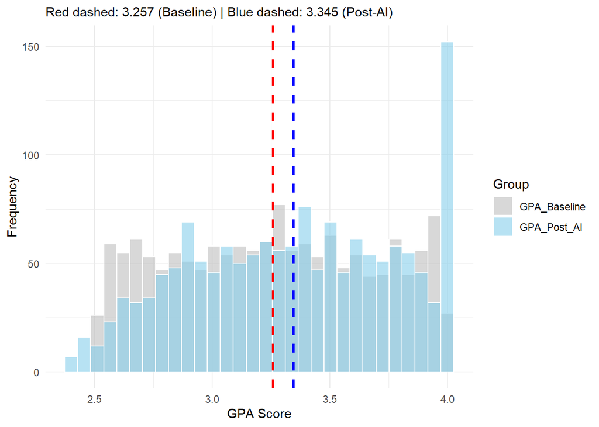

#### 4.0.3 Impact of AI Engagement Frequency on Academic Growth

The graph indicates a negligible to weak positive relationship between the frequency of AI engagement and academic growth. While AI usage is generally associated with a slight improvement in GPA (as the trend line stays above zero), increasing the daily frequency of use does not appear to provide a dramatic boost in performance.

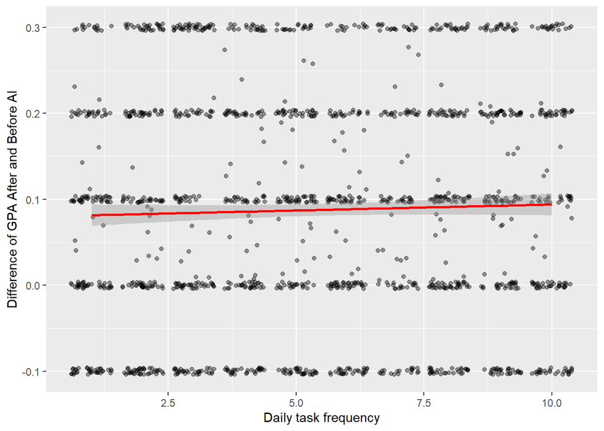

#### 4.0.4 Ethical Concern Density across Primary AI Tool Ecosystems

The heatmap reveals a clear divergence in how users of different AI platforms perceive ethical risks. While GitHub Copilot and Claude 3.5 anchor the “Low” concern spectrum with high-density clusters, Perplexity exhibits a notably higher concentration of users with “High” ethical concerns.

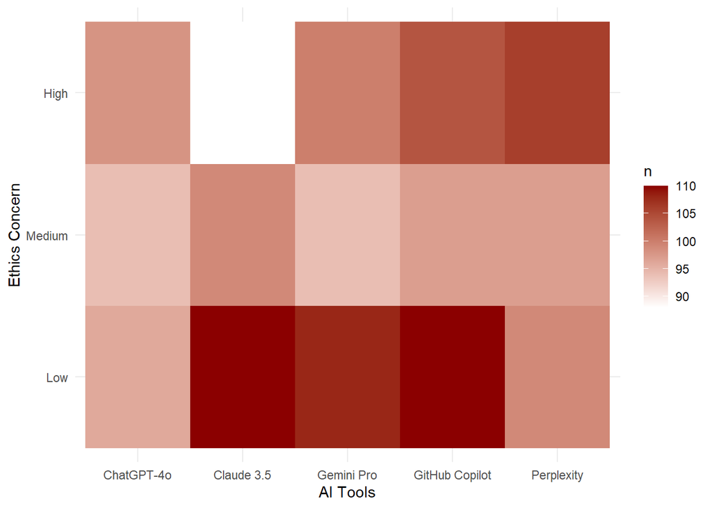

#### 4.0.5 Distribution of AI Tools

The chart displays total volume while simultaneously breaking down the internal composition of each platform’s user base. With total student counts for each tool hovering between 280 and 310, the data suggests a highly competitive landscape in which no single AI tool has yet monopolized the student market.

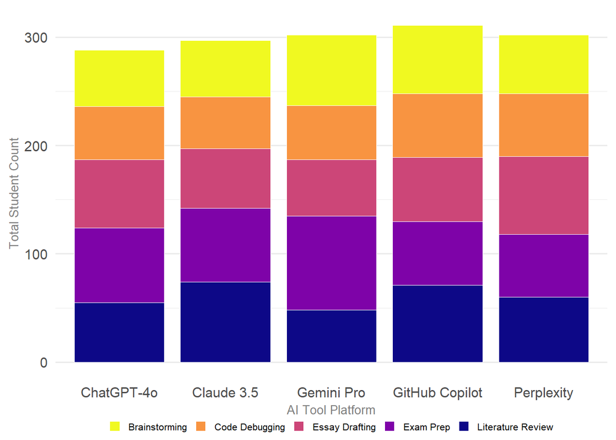

#### 4.0.6 Analysis of Weekly Time Saved

The analysis confirms that AI tools provide a substantial productivity boost for the student population. With a median saving of 9 hours per week, AI is effectively functioning as a “force multiplier,” allowing students to either reinvest that time into deeper learning or alleviate the pressures of a heavy academic workload. This significant time reclamation likely explains the high adoption rates seen across various AI platforms.

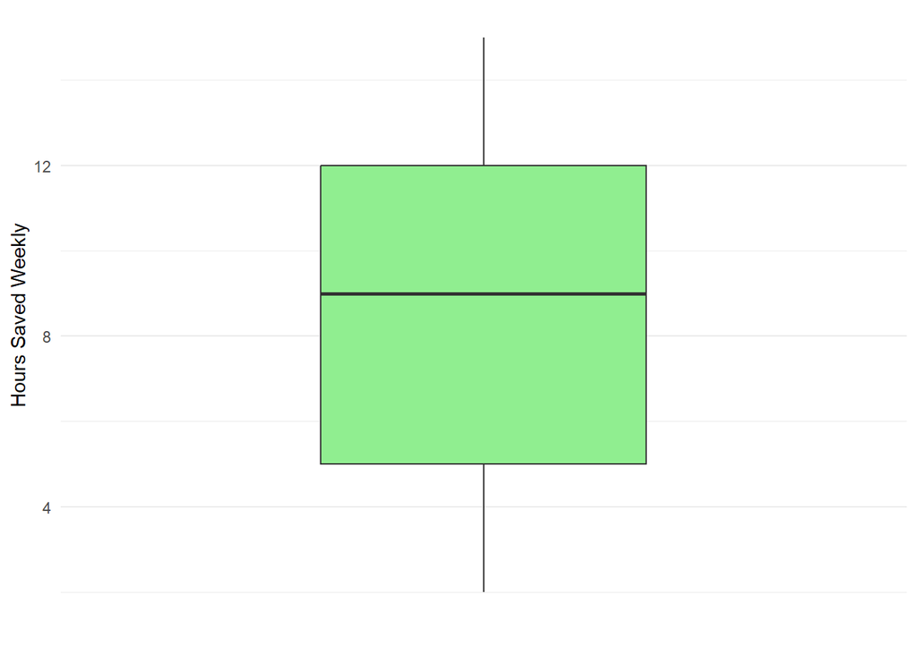

#### 4.0.7 Distribution of Task Frequency

The chart displays a near-uniform distribution with slight fluctuations, this data shows that users are spread relatively evenly across all levels of task frequency from 1 to 10 tasks per day.

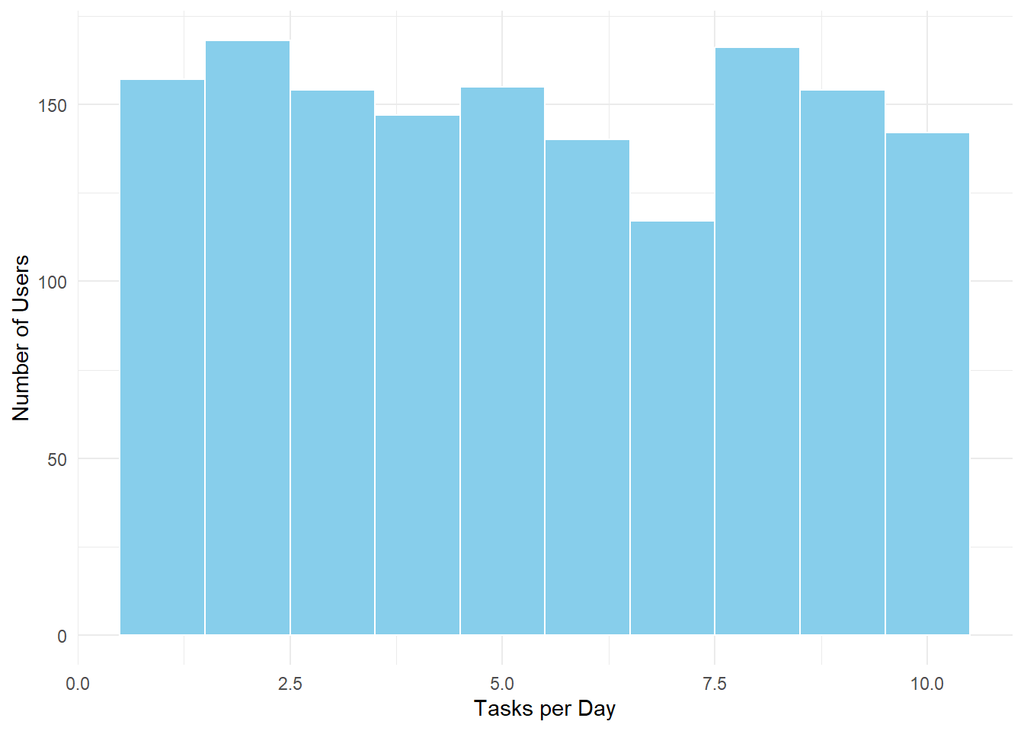

## 5 Recommendations

To capitalize on AI’s role as a productivity force multiplier, educational institutions should pivot from policing usage toward integrating AI-literacy into the core curriculum, specifically targeting students in the lower GPA tiers where the tool acts as a critical equalizer.

Given that career confidence is largely decoupled from AI proficiency and academic major, schools should also implement holistic career development programs that focus on human-centric soft skills—such as leadership, ethical reasoning, and adaptability—which AI cannot replicate.

Finally, developers and educators must address the “ethical divide” by fostering transparent dialogues about data provenance and algorithmic bias, ensuring that the critical mindset seen in Perplexity users becomes a standard competency across all platforms to prevent passive or unethical over-reliance.

## 6 Conclusions

Furthermore, the data reveals that professional self-assurance is largely decoupled from technical AI proficiency. Instead, career confidence appears to be driven by “non-computable” traits—such as leadership and adaptability—which technical integration alone cannot replicate.

Ultimately, the future of AI in education will not be defined by tool adoption, but by the user’s ability to balance productivity gains with a rigorous commitment to ethical integrity and the development of these essential human-centric skills.

## 7 Disclaimer

This report was developed for educational purposes only. The analysis utilizes an artificially generated dataset sourced from Kaggle to simulate real-world exploratory data analysis (EDA) and professional documentation practices. All statistical modeling, including the regression analysis used to evaluate variable correlations, was performed using the R programming language. This project is intended to demonstrate data science workflows and technical proficiency in statistical computing.